# Reproducible_research_project_2

Marlon Vinan

2/2/2018

# Impact of storms in United States

## Sinopsys

This is an important data analysis using R about the **Storm Data** published by the National Oceanic and Atmospheric Administration collected from 1950 - 2011. The aim of this work is try to respond i) Across the United States, which types of events are most harmful with respect to population health? and ii) Across the United States, which types of events have the greatest economic consequences?. With this background, the analysis was done using R where it shows that the most number of injuries was caused by tornado event with 26674 injuries and the most number of fatalitites was caused by excesive heat with 1903 fatalities. About the impact of economy, this data shows us that the worst event was the flood with 144 billion dolars of property damage, and the worst event for crop was drought with 14 billion of loss.  
…..

## Cofiguration Libraries

```r
echo = TRUE  # Allow code to always be displayed
options(scipen = 1)  # Turn off scientific notation.
library(ggplot2)
```

## Data processing

```r
setwd("/Users/marlonvinan/Documents/Doctorado/Reproducible_research_course/project2" )
filename <- "stormData.csv.bz2"
if(!file.exists(filename)){
    download.file("https://d396qusza40orc.cloudfront.net/repdata%2Fdata%2FStormData.csv.bz2", destfile = "stormData.csv.bz2")
}
stormData <- read.csv("stormData.csv.bz2", sep = ",")
dim(stormData)
```

```
## [1] 902297     37
```

```r
head(stormData)
```

```
##   STATE__           BGN_DATE BGN_TIME TIME_ZONE COUNTY COUNTYNAME STATE
## 1       1  4/18/1950 0:00:00     0130       CST     97     MOBILE    AL
## 2       1  4/18/1950 0:00:00     0145       CST      3    BALDWIN    AL
## 3       1  2/20/1951 0:00:00     1600       CST     57    FAYETTE    AL
## 4       1   6/8/1951 0:00:00     0900       CST     89    MADISON    AL
## 5       1 11/15/1951 0:00:00     1500       CST     43    CULLMAN    AL
## 6       1 11/15/1951 0:00:00     2000       CST     77 LAUDERDALE    AL
##    EVTYPE BGN_RANGE BGN_AZI BGN_LOCATI END_DATE END_TIME COUNTY_END
## 1 TORNADO         0                                               0
## 2 TORNADO         0                                               0
## 3 TORNADO         0                                               0
## 4 TORNADO         0                                               0
## 5 TORNADO         0                                               0
## 6 TORNADO         0                                               0
##   COUNTYENDN END_RANGE END_AZI END_LOCATI LENGTH WIDTH F MAG FATALITIES
```

[output cut: 20 more lines]

There are 902297 rows with 37 variables or columns the next step is trasnform the BGN_DATE as DATE and after that get the year

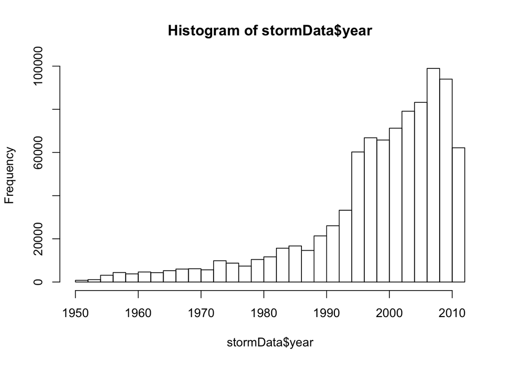

```r
stormData$year <- as.numeric(format(as.Date(stormData$BGN_DATE, format = "%m/%d/%Y %H:%M:%S"), "%Y"))

hist(stormData$year, breaks = 30)
```

As we can see on the histogram above, the events begins to increment from 1990. The subset data from 1990 will be used.

```r
storms <- stormData[stormData$year >= 1990,]
dim(storms)
```

```
## [1] 751740     38
```

After subsetting the data, the dimension is reduced to 751740 rows with 38 variables included ‘year’

## Impact in public Health

In this chunk of code, I will try to get the number of **fatalities** and **injuries** that are caused by storms from 1990 to 2011. We sort in descending order to get the top 20 events by number of injuries and fatalities. Finally we can note that the highest number of injuries was produced by **TORNADO** and for fatalities was the **EXCESSIVE HEAT**

```r
############################ INJURIES ##############################
injuries <- aggregate(storms$INJURIES, by = list(storms$EVTYPE), FUN = "sum")
colnames(injuries) <- c("EVTYPE", "INJURIES")

injuries <- data.frame(injuries)
injuries <- injuries[order(-injuries$INJURIES),]
### top 20 INJURIES
injuries <- injuries[1:20,]
injuries$EVTYPE <- factor(x = injuries$EVTYPE, levels = injuries$EVTYPE)
############################ FATALITIES ##############################
fatalities <- aggregate(storms$FATALITIES, by = list(storms$EVTYPE), FUN = "sum")
colnames(fatalities) <- c("EVTYPE", "FATALITIES")

fatalities <- data.frame(fatalities)
fatalities <- fatalities[order(-fatalities$FATALITIES),]
### top 20 INJURIES
fatalities <- fatalities[1:20,]
fatalities$EVTYPE <- factor(x = fatalities$EVTYPE, levels = fatalities$EVTYPE)

injuries[1,]
```

```
##      EVTYPE INJURIES
## 834 TORNADO    26674
```

```r
fatalities[1,]
```

```
##             EVTYPE FATALITIES
## 130 EXCESSIVE HEAT       1903
```

## Impact on Economy

Next, I will try to found the impact on economy using PROPDMGEXP and CROPDMGEXP. First of all, we convert these variables to numeric values.

```r
###################### PROPERTY DAMAGE ########################
storms$PROPDMGEXP <- as.character(toupper(storms$PROPDMGEXP))

index <- which(colnames(storms) == "PROPDMGEXP")
storms[!is.na(storms[, index]) & storms$PROPDMGEXP == "B", index] <- "9"
storms[!is.na(storms[, index]) & storms$PROPDMGEXP == "M", index] <- "6"
storms[!is.na(storms[, index]) & storms$PROPDMGEXP == "K", index] <- "3"
storms[!is.na(storms[, index]) & storms$PROPDMGEXP == "H", index] <- "2"
storms[!is.na(storms[, index]) & storms$PROPDMGEXP == "", index] <- "0"
storms$PROPDMGEXP <- as.numeric(storms$PROPDMGEXP)
storms[is.na(storms[, index]), index] <- 0
storms$propertyDamage <- storms[, index - 1] * 10 ^ storms$PROPDMGEXP


###################### CROP DAMAGE ########################
storms$CROPDMGEXP <- as.character(toupper(storms$CROPDMGEXP))
index1 <- which(colnames(storms) == "CROPDMGEXP")
storms[!is.na(storms[, index1]) & storms$CROPDMGEXP == "B", index1] <- "9"
storms[!is.na(storms[, index1]) & storms$CROPDMGEXP == "M", index1] <- "6"
storms[!is.na(storms[, index1]) & storms$CROPDMGEXP == "K", index1] <- "3"
storms[!is.na(storms[, index1]) & storms$CROPDMGEXP == "H", index1] <- "2"
storms[!is.na(storms[, index1]) & storms$CROPDMGEXP == "", index1] <- "0"
storms$CROPDMGEXP <- as.numeric(storms$CROPDMGEXP)
storms[is.na(storms[, index1]), index1] <- 0
storms$cropDamage <- storms[, index1 - 1] * 10 ^ storms$CROPDMGEXP

#######################################################
property <- aggregate(storms$propertyDamage, by = list(storms$EVTYPE), FUN = "sum")
colnames(property) <- c("EVTYPE", "propertyDamage")
property <- data.frame(property)
property <- property[order(-property$propertyDamage),]
### top 20 property
property <- property[1:20,]
property$EVTYPE <- factor(x = property$EVTYPE, levels = property$EVTYPE)

#######################################################
crop <- aggregate(storms$cropDamage, by = list(storms$EVTYPE), FUN = "sum")
colnames(crop) <- c("EVTYPE", "cropDamage")
crop <- data.frame(crop)
crop <- crop[order(-crop$cropDamage),]
### top 20 crop
crop <- crop[1:20,]
crop$EVTYPE <- factor(x = crop$EVTYPE, levels = crop$EVTYPE)
```

## Results

We have got a sorted list with severe events. Specifically, top 20 number of **fatalities** and **injuries** caused by storms events.

```r
library(ggplot2)
#require(gridExtra)
fatalities
```

```
##                      EVTYPE FATALITIES
## 130          EXCESSIVE HEAT       1903
## 834                 TORNADO       1752
## 153             FLASH FLOOD        978
## 275                    HEAT        937
## 464               LIGHTNING        816
## 170                   FLOOD        470
## 585             RIP CURRENT        368
## 856               TSTM WIND        327
## 359               HIGH WIND        248
## 19                AVALANCHE        224
## 972            WINTER STORM        206
## 586            RIP CURRENTS        204
## 278               HEAT WAVE        172
## 140            EXTREME COLD        160
## 760       THUNDERSTORM WIND        133
## 310              HEAVY SNOW        127
## 141 EXTREME COLD/WIND CHILL        125
## 676             STRONG WIND        103
## 30                 BLIZZARD        101
## 350               HIGH SURF        101
```

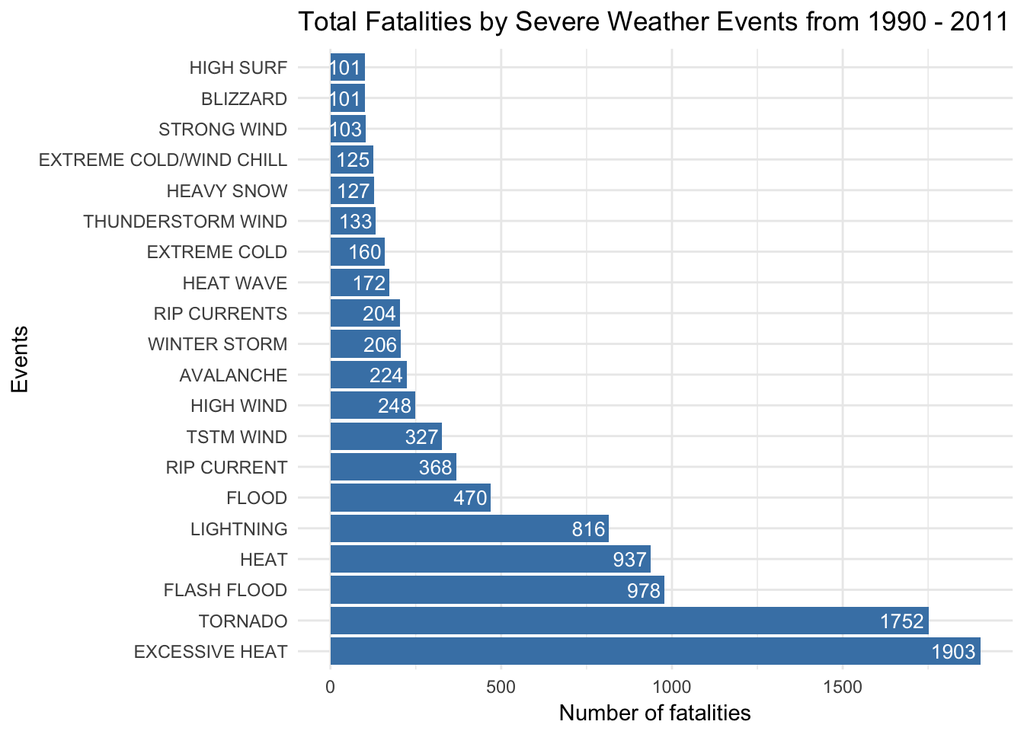

```r
ggplot(data=fatalities, aes(x=fatalities$EVTYPE, y=fatalities$FATALITIES)) +
  geom_bar(stat="identity", fill="steelblue")+ coord_flip() +
  geom_text(aes(label=fatalities$FATALITIES), hjust=1.1, color="white", size=3.5)+
    ggtitle("Total Fatalities by Severe Weather Events from 1990 - 2011")+
    ylab("Number of fatalities") + xlab("Events")+
  theme_minimal()
```

```r
injuries
```

```
##                 EVTYPE INJURIES
## 834            TORNADO    26674
## 170              FLOOD     6789
## 130     EXCESSIVE HEAT     6525
## 464          LIGHTNING     5230
## 856          TSTM WIND     5022
## 275               HEAT     2100
## 427          ICE STORM     1975
## 153        FLASH FLOOD     1777
## 760  THUNDERSTORM WIND     1488
## 972       WINTER STORM     1321
## 411  HURRICANE/TYPHOON     1275
## 244               HAIL     1139
## 359          HIGH WIND     1137
## 310         HEAVY SNOW     1021
## 957           WILDFIRE      911
## 786 THUNDERSTORM WINDS      908
## 30            BLIZZARD      805
## 188                FOG      734
## 955   WILD/FOREST FIRE      545
## 117         DUST STORM      440
```

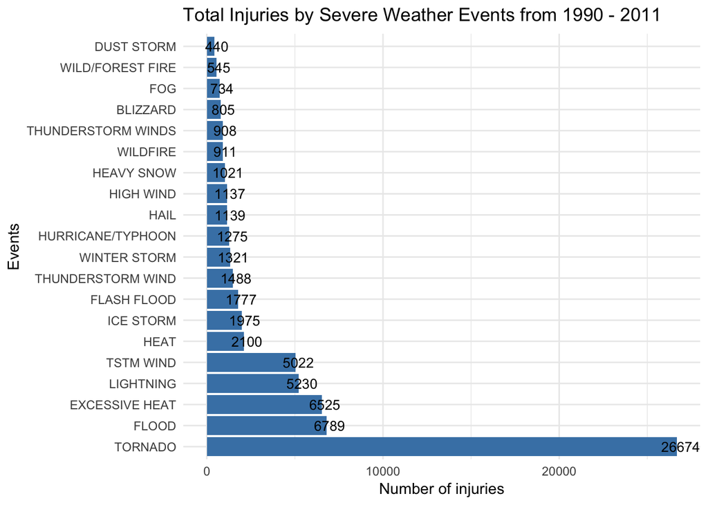

```r
ggplot(data=injuries, aes(x=injuries$EVTYPE, y=injuries$INJURIES)) +
  geom_bar(stat="identity", fill="steelblue")+ coord_flip() +
  geom_text(aes(label=injuries$INJURIES), hjust=0.4,  size=3.5)+
    ggtitle("Total Injuries by Severe Weather Events from 1990 - 2011")+
    ylab("Number of injuries") + xlab("Events")+
  theme_minimal()
```

```r
#grid.arrange(pfatalities, pinjuries, nrow = 2)
```

Based on the above figures, we found that the **excesive heat** and **tornado** caused the most fatalities. On the other hand, the **tornado** and **flood** caused the most injuries In the U.S.A. from 1990 to 2011.

The same analysis was done for the impact on economy. We’ve got two sorted lists by the amount of money cost by damage

```r
library(ggplot2)
property
```

```
##                        EVTYPE propertyDamage
## 170                     FLOOD   144657709807
## 411         HURRICANE/TYPHOON    69305840000
## 670               STORM SURGE    43323536000
## 834                   TORNADO    30468735506
## 153               FLASH FLOOD    16822673978
## 244                      HAIL    15735267513
## 402                 HURRICANE    11868319010
## 848            TROPICAL STORM     7703890550
## 972              WINTER STORM     6688497251
## 359                 HIGH WIND     5270046295
## 590               RIVER FLOOD     5118945500
## 957                  WILDFIRE     4765114000
## 671          STORM SURGE/TIDE     4641188000
## 856                 TSTM WIND     4484928495
## 427                 ICE STORM     3944927860
## 760         THUNDERSTORM WIND     3483122472
## 408            HURRICANE OPAL     3172846000
## 955          WILD/FOREST FIRE     3001829500
## 299 HEAVY RAIN/SEVERE WEATHER     2500000000
## 786        THUNDERSTORM WINDS     1944590859
```

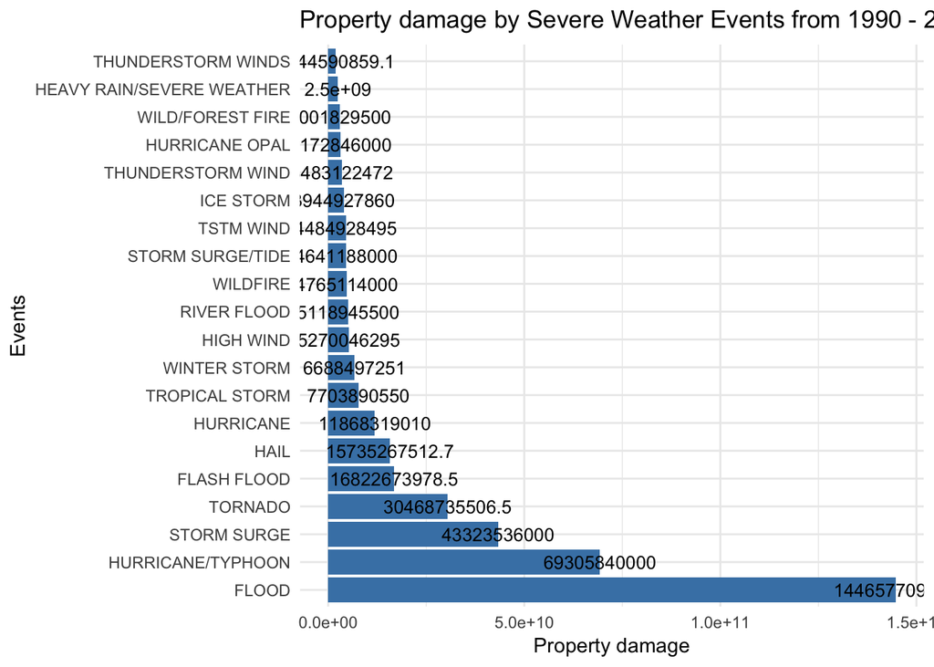

```r
ggplot(data=property, aes(x=property$EVTYPE, y=property$propertyDamage)) +
  geom_bar(stat="identity", fill="steelblue")+ coord_flip() +
  geom_text(aes(label=property$propertyDamage),  size=3.5)+
    ggtitle("Property damage by Severe Weather Events from 1990 - 2011")+
    ylab("Property damage") + xlab("Events")+
  theme_minimal()
```

```r
crop
```

```
##                EVTYPE  cropDamage
## 95            DROUGHT 13972566000
## 170             FLOOD  5661968450
## 590       RIVER FLOOD  5029459000
## 427         ICE STORM  5022113500
## 244              HAIL  3025954473
## 402         HURRICANE  2741910000
## 411 HURRICANE/TYPHOON  2607872800
## 153       FLASH FLOOD  1421317100
## 140      EXTREME COLD  1292973000
## 212      FROST/FREEZE  1094086000
## 290        HEAVY RAIN   733399800
## 848    TROPICAL STORM   678346000
## 359         HIGH WIND   638571300
## 856         TSTM WIND   554007350
## 130    EXCESSIVE HEAT   492402000
## 192            FREEZE   446225000
## 834           TORNADO   414953270
## 760 THUNDERSTORM WIND   414843050
## 275              HEAT   401461500
## 957          WILDFIRE   295472800
```

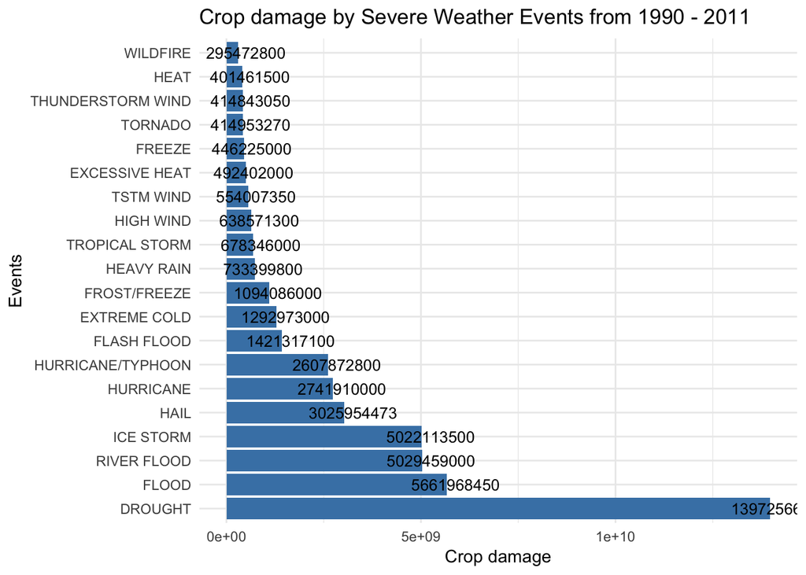

```r
ggplot(data=crop, aes(x=crop$EVTYPE, y=crop$cropDamage)) +
  geom_bar(stat="identity", fill="steelblue")+ coord_flip() +
  geom_text(aes(label=crop$cropDamage), hjust=0.4,  size=3.5)+
    ggtitle("Crop damage by Severe Weather Events from 1990 - 2011")+
    ylab("Crop damage") + xlab("Events")+
  theme_minimal()
```

As we can see on the figures above, we found that **flood** and **hurricane/typhoon** was the most destructive and they caused the most damage to property. On the other hand, **drought** and **flood** caused the most crop damage in U.S.A from 1990 to 2011

## Conclusion

This data can show us that **excesive heat**and **tornado** caused more fatalities than others events and the **tornado** caused the most injuries. The impact on economy was that the **flood** and **drought** caused the most damage in property and crop respectively.